# NHS Borders Cancer Rates

Marcus Eilertsen

02/05/2022

## 1. Documentation

The aim of this report is to assist with the planning for provision of cancer treatment services in the NHS Borders Health Board.

This will be accomplished through the use of analysis and key visualisations of open data provided by Public Health Scotland. The data itself does not contain any personally identifiable information.

All visualisations were made in RStudio using the ggplot package.

## 2. Analysis

### Visualisations

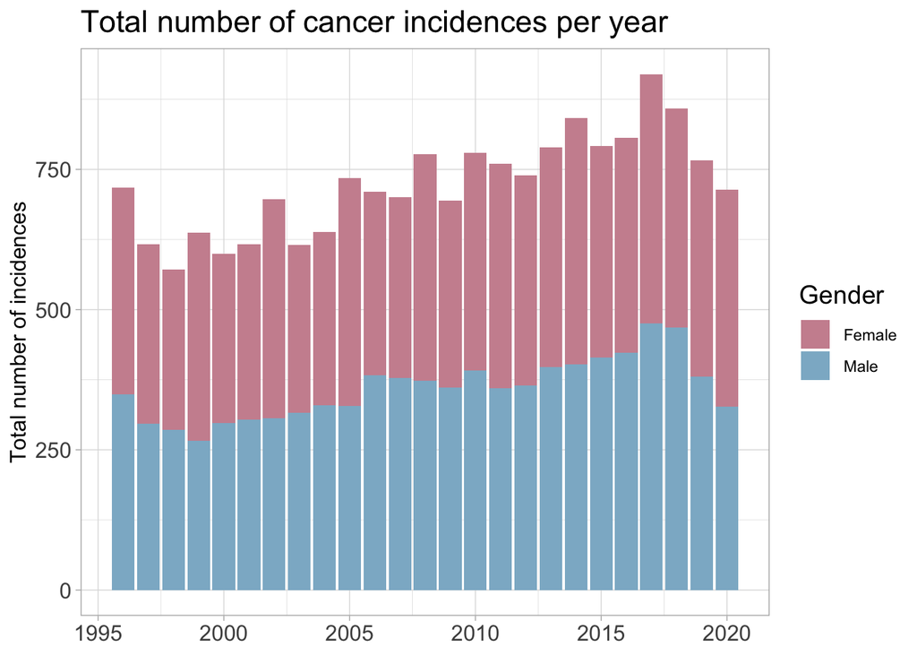

This bar plot shows the total number of cancer incidences each year, between 1996 and 2020. We can observe an upward trend overall, with a localised decline between 2017 and 2020.

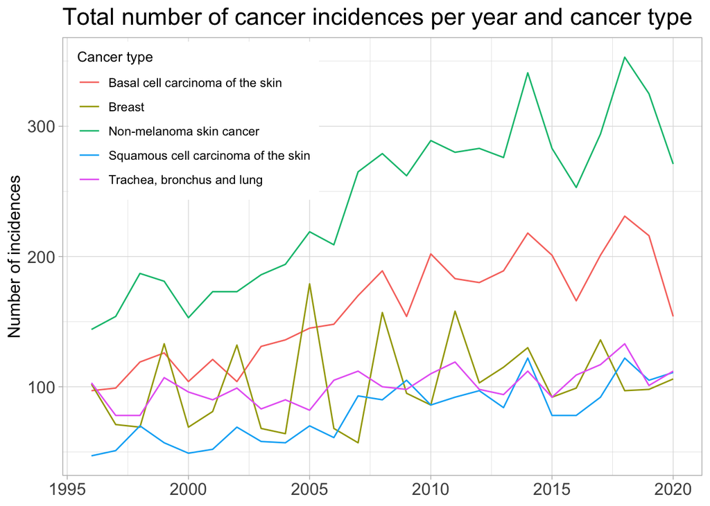

This line graph shows the five most common types of cancer and their incidences between 1996 and 2020. We can see a steady rise in incidences of non-melanoma skin cancer and basal cell carcinoma of the skin.

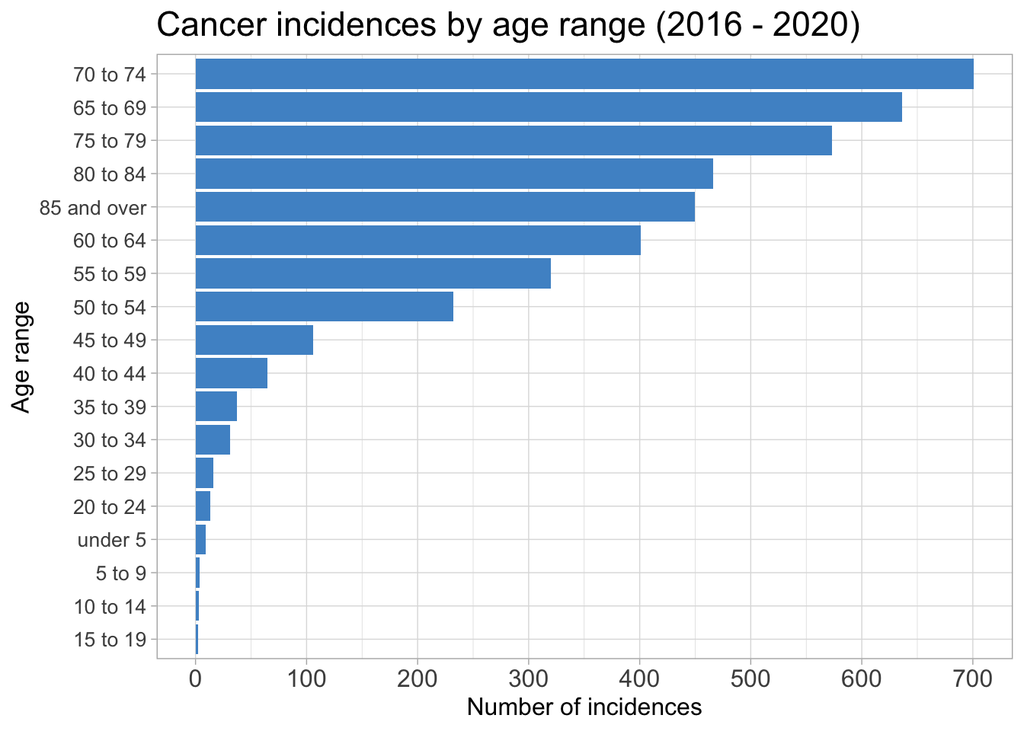

This bar plot shows the number of incidences across all cancer types, sorted by age range, from most to least affected. We can see that people aged 70 to 74 are most affected. The data used for this visualisation covers a five year period between 2016 and 2020.

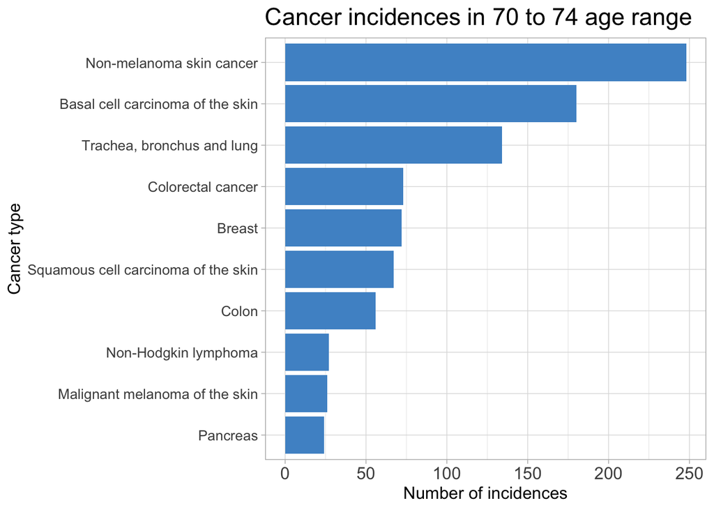

This bar plot shows the incidences of the 10 most common types of cancer for the 70 to 74 age range. As with the previous visualisation, the data for this graph covers a five year period between 2016 and 2020.

### Cancer type prevalence table

**Drop-down table detailing most common types of cancer by age range**

| Cancer type | Age range | Incidences |
| --- | --- | --- |
| Colorectal cancer | 10 to 14 | 1 |
| Colon | 10 to 14 | 1 |
| Leukaemias | 10 to 14 | 1 |
| Malignant brain cancer | 15 to 19 | 1 |
| Malig brain ca (incl pit. gland, cranio. duct, pineal gland) | 15 to 19 | 1 |
| All brain and CNS tumours (malignant and non-malignant) | 15 to 19 | 1 |
| Thyroid | 15 to 19 | 1 |
| Non-malig brain ca (incl pit.gland,cranio.duct,pineal gland) | 20 to 24 | 2 |
| All brain and CNS tumours (malignant and non-malignant) | 20 to 24 | 2 |
| Leukaemias | 20 to 24 | 2 |
| Acute lymphoblastic leukaemia | 20 to 24 | 2 |
| Malignant melanoma of the skin | 20 to 24 | 2 |
| Non-malig brain ca (incl pit.gland,cranio.duct,pineal gland) | 25 to 29 | 4 |
| All brain and CNS tumours (malignant and non-malignant) | 25 to 29 | 4 |
| Breast | 25 to 29 | 4 |
| Non-melanoma skin cancer | 30 to 34 | 9 |
| Basal cell carcinoma of the skin | 30 to 34 | 9 |
| Breast | 35 to 39 | 12 |
| Breast | 40 to 44 | 14 |
| Non-melanoma skin cancer | 45 to 49 | 35 |
| Leukaemias | 5 to 9 | 3 |
| Acute lymphoblastic leukaemia | 5 to 9 | 3 |
| Breast | 50 to 54 | 69 |
| Non-melanoma skin cancer | 55 to 59 | 81 |
| Non-melanoma skin cancer | 60 to 64 | 118 |
| Non-melanoma skin cancer | 65 to 69 | 145 |
| Non-melanoma skin cancer | 70 to 74 | 248 |
| Non-melanoma skin cancer | 75 to 79 | 259 |
| Non-melanoma skin cancer | 80 to 84 | 238 |
| Non-melanoma skin cancer | 85 and over | 299 |
| Leukaemias | under 5 | 3 |
| Acute lymphoblastic leukaemia | under 5 | 3 |

This table shows the most common types of cancer by age range. We can observe that there isn’t one single type of cancer that is most prevalent in younger patients, whereas skin cancer in all its forms becomes very prevalent as we look at higher age ranges.

## 3. Main insights

Perhaps the main insight we can gain from this analysis is that skin cancer in all its forms is the most prevalent type of cancer across the NHS Borders Health Board.

Another finding is that both breast and lung cancer are quite common relative to many other types of cancer.

These insights can be used to further inform any planned awareness campaigns, such as informing the public of the dangers of sun exposure, smoking, and the importance of regular screening for breast cancer, for example.

Thank you for reading!

[figure not shown]